# Personal Loan Campaing

## Cost Complexity Pruning

```python
clf = DecisionTreeClassifier(random_state=1)
path = clf.cost_complexity_pruning_path(xtrain, ytrain)
ccp_alphas, impurities = path.ccp_alphas, path.impurities
```

```python
pd.DataFrame(path)
```

|  | ccp_alphas | impurities |
| --- | --- | --- |
| 0 | 0.000000 | 0.000000 |
| 1 | 0.000269 | 0.000537 |
| 2 | 0.000302 | 0.001141 |
| 3 | 0.000330 | 0.001801 |
| 4 | 0.000335 | 0.003143 |
| 5 | 0.000448 | 0.004038 |
| 6 | 0.000537 | 0.005112 |
| 7 | 0.000537 | 0.006186 |
| 8 | 0.000537 | 0.006723 |
| 9 | 0.000565 | 0.008419 |
| 10 | 0.000592 | 0.009604 |
| 11 | 0.000620 | 0.010224 |
| 12 | 0.000629 | 0.011483 |
| 13 | 0.000637 | 0.013392 |
| 14 | 0.000642 | 0.014675 |
| 15 | 0.000716 | 0.015391 |
| 16 | 0.000895 | 0.016287 |
| 17 | 0.000935 | 0.017222 |
| 18 | 0.000993 | 0.021195 |
| 19 | 0.001084 | 0.022279 |
| 20 | 0.001146 | 0.023425 |
| 21 | 0.001165 | 0.024590 |
| 22 | 0.001765 | 0.026355 |
| 23 | 0.001814 | 0.028169 |
| 24 | 0.004057 | 0.032226 |
| 25 | 0.004171 | 0.036396 |
| 26 | 0.005529 | 0.041926 |
| 27 | 0.012739 | 0.067404 |
| 28 | 0.027807 | 0.123019 |
| 29 | 0.048384 | 0.171403 |

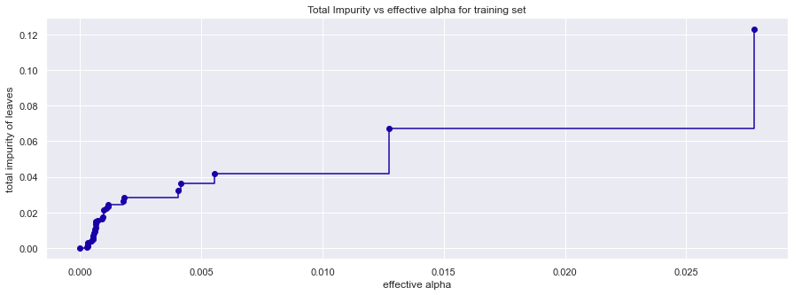

```python
fig, ax = plt.subplots(figsize=(15,5))
ax.plot(ccp_alphas[:-1], impurities[:-1], marker='o', drawstyle="steps-post")
ax.set_xlabel("effective alpha")
ax.set_ylabel("total impurity of leaves")
ax.set_title("Total Impurity vs effective alpha for training set")
plt.show()
```

```python
clfs = []
for ccp_alpha in ccp_alphas:
    clf = DecisionTreeClassifier(random_state=1, ccp_alpha=ccp_alpha)
    clf.fit(xtrain, ytrain)
    clfs.append(clf)
print("Number of nodes in the last tree is: {} with ccp_alpha: {}".format(
      clfs[-1].tree_.node_count, ccp_alphas[-1]))
```

```
Number of nodes in the last tree is: 1 with ccp_alpha: 0.04838388735079932
```

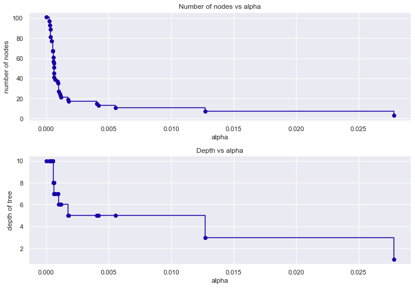

```python
clfs = clfs[:-1]
ccp_alphas = ccp_alphas[:-1]

node_counts = [clf.tree_.node_count for clf in clfs]
depth = [clf.tree_.max_depth for clf in clfs]
fig, ax = plt.subplots(2, 1,figsize=(10,7))
ax[0].plot(ccp_alphas, node_counts, marker='o', drawstyle="steps-post")
ax[0].set_xlabel("alpha")
ax[0].set_ylabel("number of nodes")
ax[0].set_title("Number of nodes vs alpha")
ax[1].plot(ccp_alphas, depth, marker='o', drawstyle="steps-post")
ax[1].set_xlabel("alpha")
ax[1].set_ylabel("depth of tree")
ax[1].set_title("Depth vs alpha")
fig.tight_layout()
```

## Recall vs alpha for training and testing sets

```python
recall_train=[]
for clf in clfs:
    pred_train3=clf.predict(xtrain)
    values_train=metrics.recall_score(ytrain,pred_train3)
    recall_train.append(values_train)
```

```python
recall_test=[]
for clf in clfs:
    pred_test3=clf.predict(xtest)
    values_test=metrics.recall_score(ytest,pred_test3)
    recall_test.append(values_test)
```

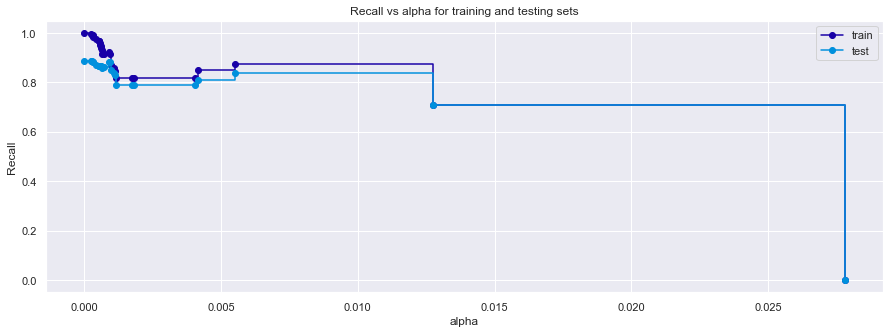

```python
fig, ax = plt.subplots(figsize=(15,5))
ax.set_xlabel("alpha")
ax.set_ylabel("Recall")
ax.set_title("Recall vs alpha for training and testing sets")
ax.plot(ccp_alphas, recall_train, marker='o', label="train",
        drawstyle="steps-post")
ax.plot(ccp_alphas, recall_test, marker='o', label="test",
        drawstyle="steps-post")
ax.legend()
plt.show()
```

```python
# creating the model where we get highest train and test recall
index_best_model = np.argmax(recall_test)
best_model = clfs[index_best_model]
print(best_model)
```

```
DecisionTreeClassifier(random_state=1)
```

```python
get_recall_score(best_model)
```

```
Recall on training set :  1.0
Recall on test set :  0.8871794871794871
```

## Confusion Matrix

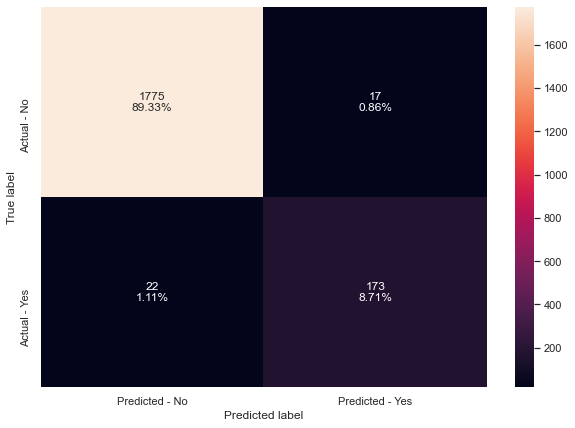

```python
make_confusion_matrix(best_model,ytest)
```

## Visualizing Decision Tree

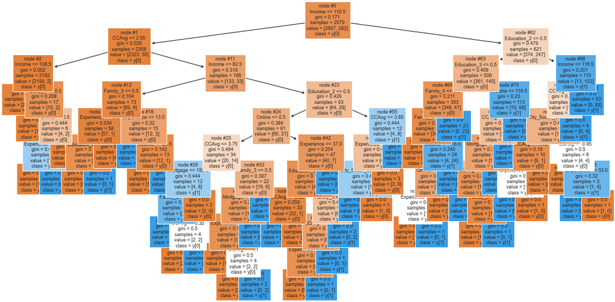

```python
plt.figure(figsize=(20,10))

out = tree.plot_tree(best_model,feature_names=feature_names,filled=True,fontsize=9,node_ids=True,class_names=True)
for o in out:
     arrow = o.arrow_patch
     if arrow is not None:
        arrow.set_edgecolor('black')
        arrow.set_linewidth(1)
plt.show()
plt.show()
```

```python
# importance of features in the tree building ( The importance of a feature is computed as the
#(normalized) total reduction of the 'criterion' brought by that feature. It is also known as the Gini importance )

print (pd.DataFrame(best_model.feature_importances_, columns = ["Imp"], index = xtrain.columns).sort_values(by = 'Imp', ascending = False))
```

```
                      Imp
Income           0.364283
Education_3      0.195330
Education_2      0.142580
Family_3         0.091084
Family_4         0.075859
CCAvg            0.070546
Experience       0.030880
Mortgage         0.012567
Online           0.009124
City_South_Cali  0.005397
Family_2         0.002350
CreditCard       0.000000
```

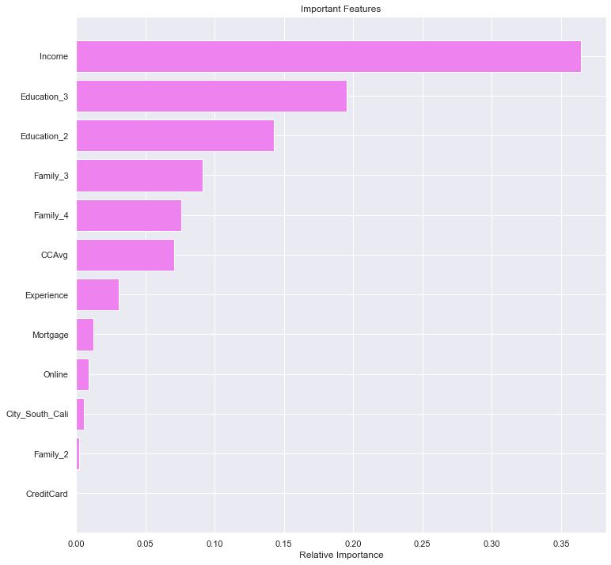

```python
importances = best_model.feature_importances_
indices = np.argsort(importances)

plt.figure(figsize=(12,12))
plt.title('Important Features')
plt.barh(range(len(indices)), importances[indices], color='violet', align='center')
plt.yticks(range(len(indices)), [feature_names[i] for i in indices])
plt.xlabel('Relative Importance')
plt.show()
```

##### Observations

- Income, Education_3, and Education_2 remain most important features post pruning

## Comparing all the decision tree models

```python
comparison_frame = pd.DataFrame({'Model':['Initial decision tree model','Decision treee with hyperparameter tuning',
                                         'Decision tree with post-pruning'], 'Train_Recall':[1,0.94,1], 'Test_Recall':[0.88,0.86,0.88]})
comparison_frame
```

|  | Model | Train_Recall | Test_Recall |
| --- | --- | --- | --- |
| 0 | Initial decision tree model | 1.00 | 0.88 |
| 1 | Decision treee with hyperparameter tuning | 0.94 | 0.86 |
| 2 | Decision tree with post-pruning | 1.00 | 0.88 |

## Business Insights

- Income, Education_3 (Advanced/Professional), Education_2 (Graduate Degree) are the 3 most important variables when determining if a customer will get a personal loan
- 291 customers that have a personal loan go online for bank services
- 142 customers that have a personal loan have a credit card
- 204 customers that have an advanced/professional education have personal loans
- 180 customers that have a graduate degree have a personal loan
- 133 customers that have more family size of 4 have personal loans. More than family sizes of 1,2,3
- 240 customers that live in South California have personal loans
- customers between 0-41 years of experience working have personal loans

## Recommendations

- 2673 customers dont have a personal loan and go online for bank services
- 1316 customers dont have a personal loan but have credit cards
- 1210 customers dont have a personal loan but have a graduate degree
- 1287 customers dont have a personal loan but have advanced/professional education
- 1183 customers dont have a personal loan but have family size of 2
- 870 customers dont have a personal loan but have family size of 3
- 1082 customers dont have a personal loan but have a family size of 4
- 2259 customers dont have a personal loan but live in South California
- Target customers that have a high income of '$'70K-'$'350K with announcements and promotions while customers are navigating the online services.
- Target customers with big family sizes of 3
- Target customers with high credit card average spending per month
- Target customers with graduate degrees, advanced, professional education. They are more prone to get a personal loan.